# TUGAS Kelompok MPDW 8

Farrel Gilbran

2023-10-30

# KELOMPOK 17

1. Syifa Khairunnisa (G1401211012)
2. Radhitya Harma (G1401211021)
3. Farrel Gilbran (G1401211057)
4. Alfikri Ihsan (G1401211058)

# Call Packages

```r
library(ggplot2)
library(tsibble)
library(tseries)
library(MASS)
library(forecast)
library(TSA)
library(TTR)
library(aTSA)
library(graphics)
library(imputeTS)
```

# Input Data

Data Merupakan Harga Cabai Keriting Pada Provinsi Sumatra Barat Pada Tahun 2018-2021 per minggu

```r
library(rio)
data <- import("https://raw.githubusercontent.com/syifaskn/MPDWPraktikum/main/Data%20Kelompok/kelompok.csv")
data
```

```
##     Periode Cabai
## 1         1    NA
## 2         2 48650
## 3         3 47150
## 4         4 48750
## 5         5 51500
## 6         6 41400
## 7         7 47650
## 8         8 47400
## 9         9 45250
## 10       10 49900
## 11       11 52150
## 12       12 49150
## 13       13 46500
## 14       14 43650
```

[output cut: 195 more lines]

```r
head(data)
```

```
##   Periode Cabai
## 1       1    NA
## 2       2 48650
## 3       3 47150
## 4       4 48750
## 5       5 51500
## 6       6 41400
```

# Pengecekan Missing Value

```r
sum(is.na(data))
```

```
## [1] 3
```

# Imputasi Missing Value

```r
dataimp = na_interpolation(data, option = "spline")
head(dataimp) %>% knitr::kable(caption = "Data yang sudah diimputasi")
```

Data yang sudah diimputasi

| Periode | Cabai |
| --- | --- |
| 1 | 48650 |
| 2 | 48650 |
| 3 | 47150 |
| 4 | 48750 |
| 5 | 51500 |
| 6 | 41400 |

# Ubah Format Data time series

```r
data.ts <- ts(dataimp$Cabai)
```

# Eksplorasi Data

## Plot Data Penuh

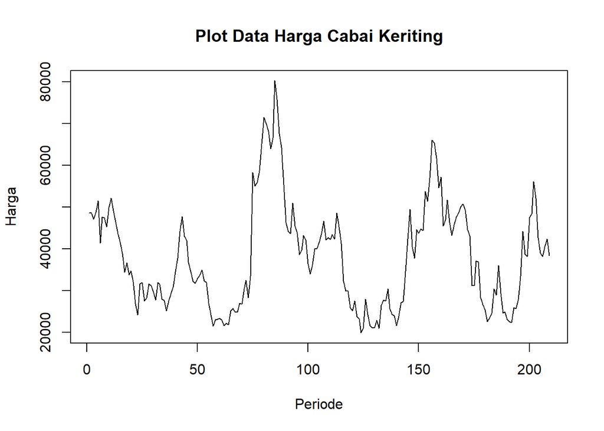

```r
plot.ts(data.ts, lty=1, xlab="Periode", ylab="Harga", main="Plot Data Harga Cabai Keriting")
```

Berdasarkan plot data deret waktu, terlihat bahwa data memiliki trend naik turun seaseonal. Berdasarkan pola data, pembagian data latih dan data uji ditetapkan dengan proporsi 80%:20%.

Berdasarkan plot data deret waktu pada data total, terlihat bahwa data cenderung memiliki trend yang turun lalu naik jauh dan cenderung tidak bergerak pada nilai tengah tertentu. Hal ini mengindikasikan bahwa data tidak stasioner dalam rataan.

## Plot Data Latih

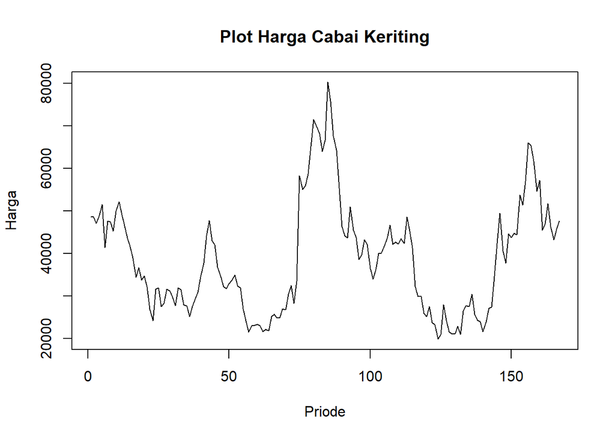

```r
datatrain<-data.ts[1:167]
train.ts<-ts(datatrain)
plot.ts(train.ts, lty=1, xlab="Priode", ylab="Harga", main="Plot Harga Cabai Keriting")
```

Berdasarkan plot data deret waktu pada data latih, terlihat bahwa data cenderung memiliki trend yang turun lalu naik seasonal dan cenderung tidak bergerak pada nilai tengah tertentu. Hal ini mengindikasikan bahwa data tidak stasioner dalam rataan.

### Plot Data Uji

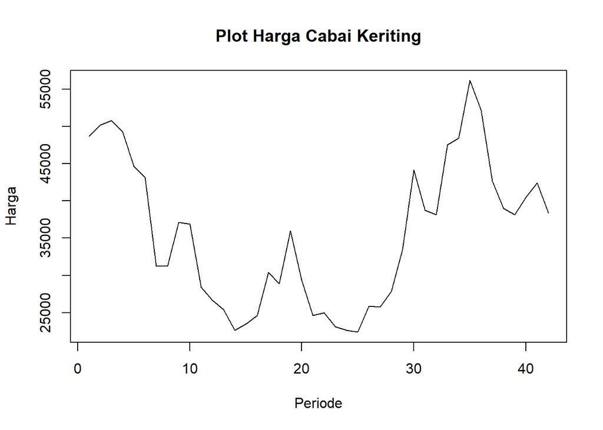

```r
datatest<-data.ts[168:209]
test.ts<-ts(datatest)
plot.ts(test.ts, lty=1, xlab="Periode", ylab="Harga", main="Plot Harga Cabai Keriting")
```

Berdasarkan plot data deret waktu pada data Uji, terlihat bahwa data cenderung memiliki trend yang turun lalu naik dan cenderung tidak bergerak pada nilai tengah tertentu. Hal ini mengindikasikan bahwa data tidak stasioner dalam rataan.

# Uji Stasioneritas Data

## Plot ACF

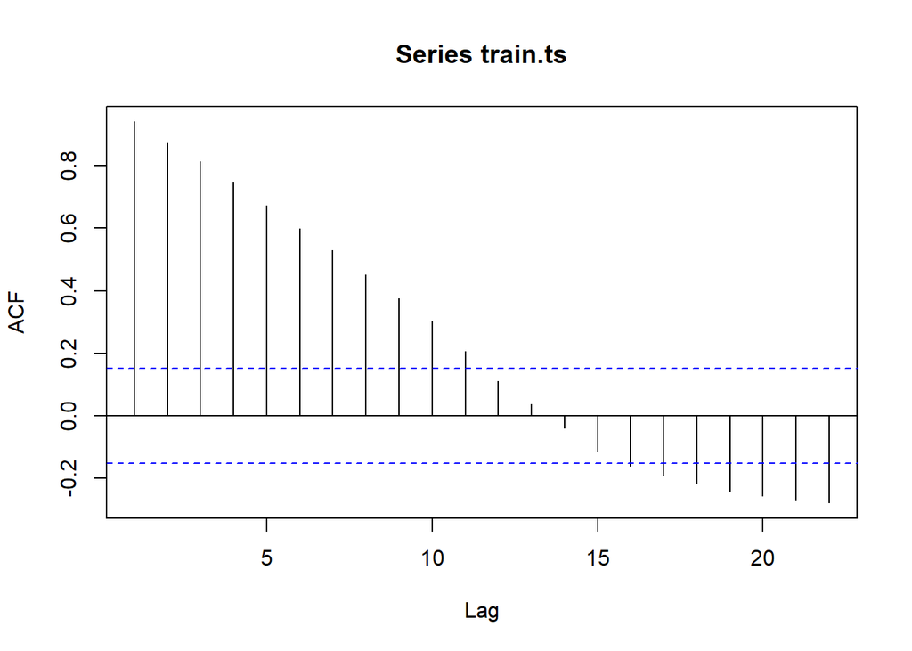

```r
acf(train.ts)
```

Berdasarkan plot ACF, terlihat bahwa plot ACF data menurun secara perlahan (*tails of slowly*). Hal ini juga menjadi indikasi bahwa data tidak stasioner dalam rataan

## Uji ADF

```r
tseries::adf.test(train.ts)
```

```
##
##  Augmented Dickey-Fuller Test
##
## data:  train.ts
## Dickey-Fuller = -2.6646, Lag order = 5, p-value = 0.2989
## alternative hypothesis: stationary
```

$H_0$ : Data tidak stasioner dalam rataan

$H_1$ : Data stasioner dalam rataan

Berdasarkan uji ADF tersebut, didapat *p-value* sebesar 0.2989 yang lebih besar dari taraf nyata 5% sehingga tak tolak $H_0$ dan menandakan bahwa data tidak stasioner dalam rataan. Hal ini sesuai dengan hasil eksplorasi menggunakan plot time series dan plot ACF, sehingga ketidakstasioneran model kedepannya harus ditangani

## Plot Box-Cox

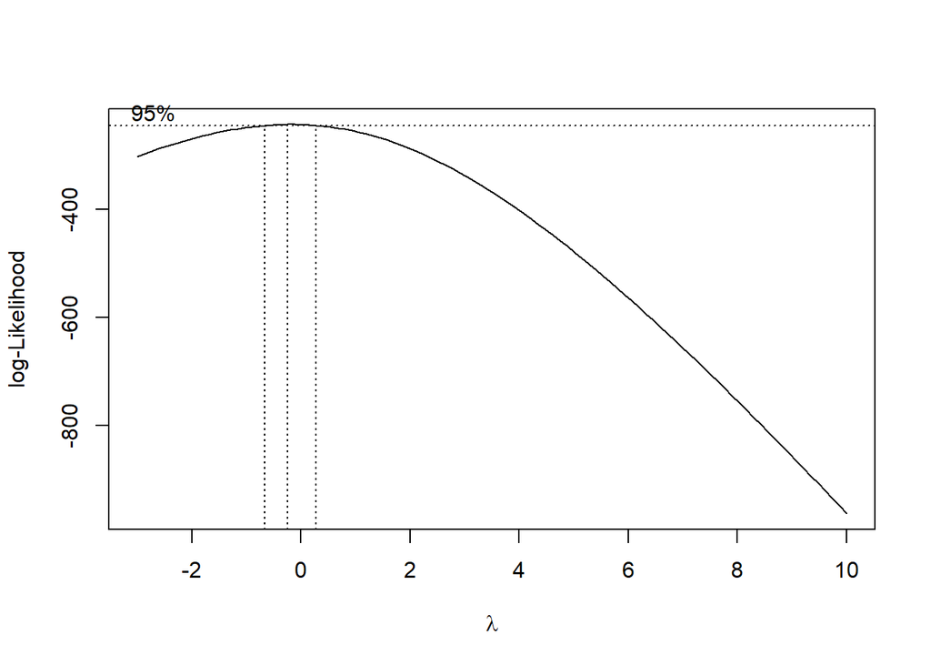

```r
index <- seq(1:167)
bc = boxcox(train.ts~index, lambda = seq(-3,10,by=1))
```

```r
#Nilai Rounded Lambda
lambda <- bc$x[which.max(bc$y)]
lambda
```

```
## [1] -0.2424242
```

```r
#SK
bc$x[bc$y > max(bc$y) - 1/2 * qchisq(.95,1)]
```

```
## [1] -0.63636364 -0.50505051 -0.37373737 -0.24242424 -0.11111111  0.02020202
## [7]  0.15151515
```

Plot Boxcox menunjukkan nilai *rounded value* ($\lambda$) optimum sebesar **-0.2424** dan pada selang kepercayaan 95% nilai memiliki batas bawah **-0.6363** dan batas atas **0.1515**. Selang tersebut tidak memuat nilai satu sehingga dapat dikatakan bahwa data bangkitan tidak stasioner dalam ragam.

## Transformasi Data

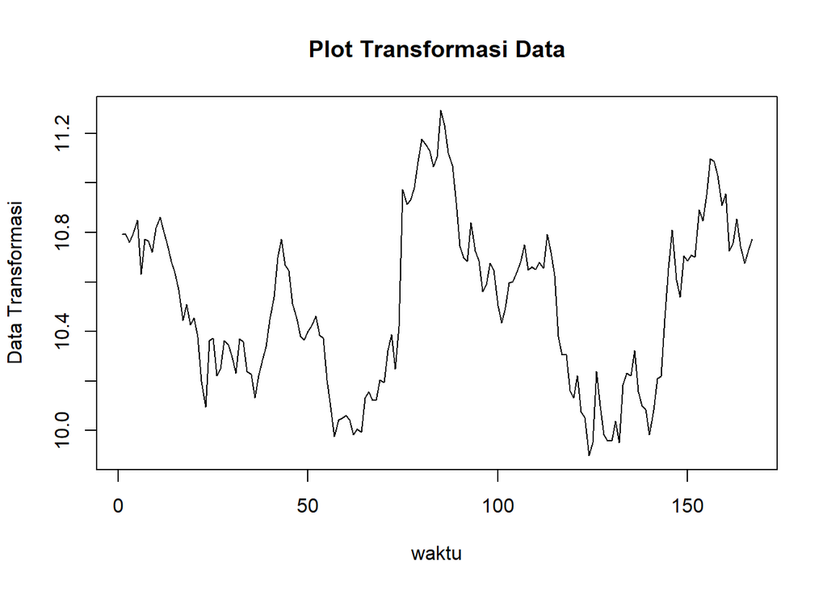

```r
train.ts.tr <- log(train.ts)
plot.ts(train.ts.tr, lty=1, xlab="waktu", ylab="Data Transformasi", main="Plot Transformasi Data")
```

## Uji Kestasioneran Data Dalam Ragam Kembali

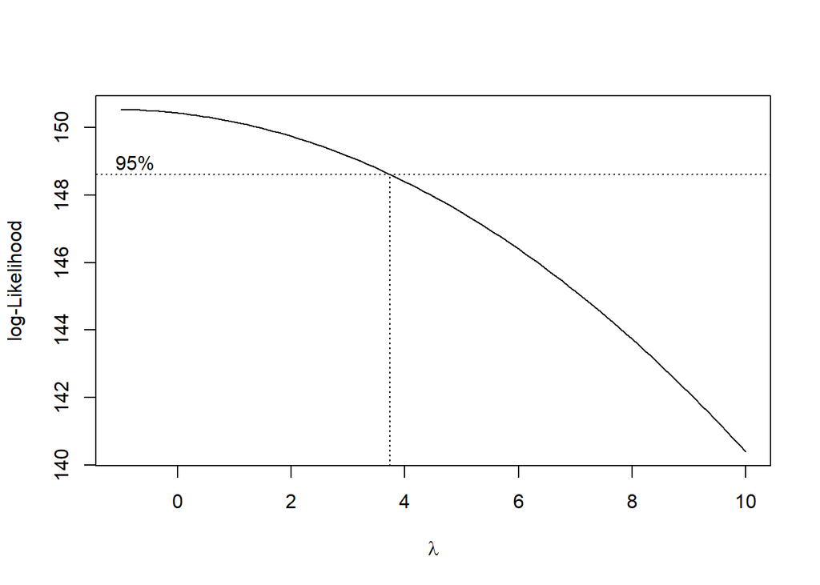

```r
index <- seq(1:167)
bc = boxcox(train.ts.tr~index, lambda = seq(-1,10,by=1))
```

```r
#Nilai Rounded Lambda
lambda <- bc$x[which.max(bc$y)]
lambda
```

```
## [1] -1
```

```r
#SK
bc$x[bc$y > max(bc$y) - 1/2 * qchisq(.95,1)]
```

```
##  [1] -1.0000000 -0.8888889 -0.7777778 -0.6666667 -0.5555556 -0.4444444
##  [7] -0.3333333 -0.2222222 -0.1111111  0.0000000  0.1111111  0.2222222
## [13]  0.3333333  0.4444444  0.5555556  0.6666667  0.7777778  0.8888889
## [19]  1.0000000  1.1111111  1.2222222  1.3333333  1.4444444  1.5555556
## [25]  1.6666667  1.7777778  1.8888889  2.0000000  2.1111111  2.2222222
## [31]  2.3333333  2.4444444  2.5555556  2.6666667  2.7777778  2.8888889
## [37]  3.0000000  3.1111111  3.2222222  3.3333333  3.4444444  3.5555556
## [43]  3.6666667
```

## Penanganan Ketidakstasioneran Data Dalam Rataan

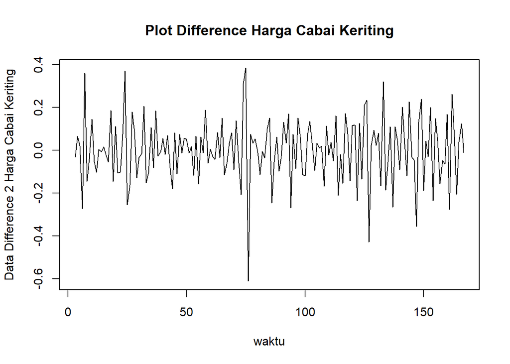

```r
train.diff<-diff(train.ts.tr,differences = 2)
plot.ts(train.diff, lty=1, xlab="waktu", ylab="Data Difference 2 Harga Cabai Keriting", main="Plot Difference Harga Cabai Keriting")
```

Berdasarkan plot data deret waktu, terlihat bahwa data sudah stasioner dalam rataan ditandai dengan data bergerak pada nilai tengah tertentu (tidak terdapat trend ataupun musiman pada data)

### Plot ACF

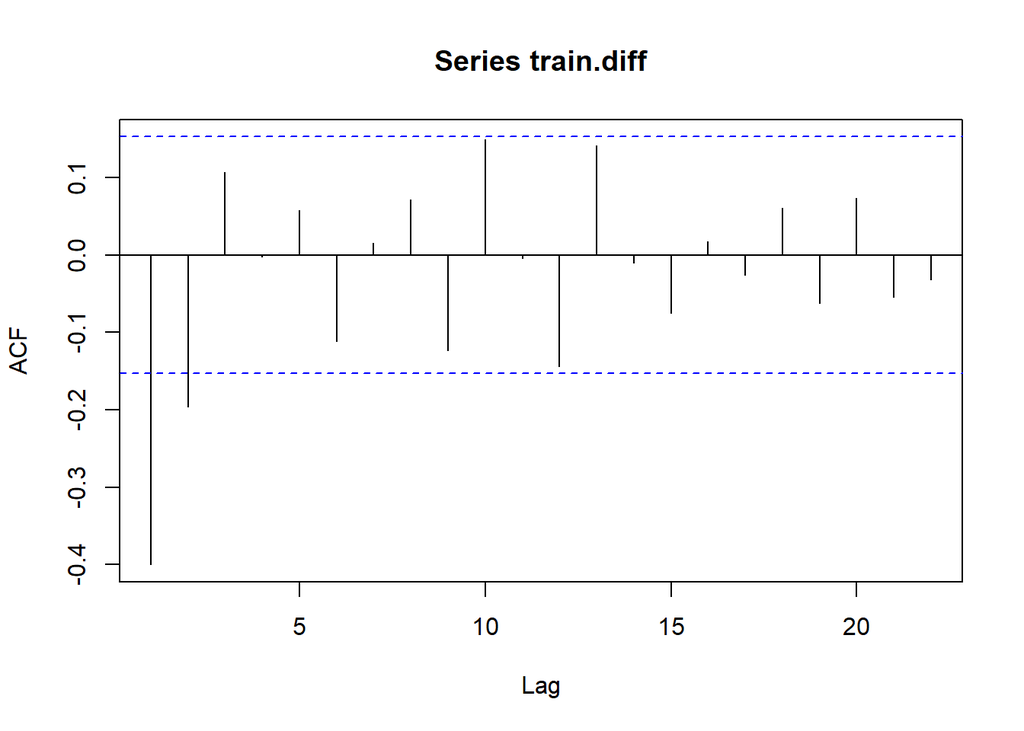

```r
acf(train.diff)
```

Berdasarkan plot tersebut, terlihat bahwa plot ACF cuts off pada lag ke 2. Hal ini menandakan data sudah stasioner dalam rataan dan ketidakstasioneran data telah berhasil tertangani.

### Uji ADF

```r
tseries::adf.test(train.diff)
```

```
##
##  Augmented Dickey-Fuller Test
##
## data:  train.diff
## Dickey-Fuller = -8.4203, Lag order = 5, p-value = 0.01
## alternative hypothesis: stationary
```

$H_0$ : Data tidak stasioner dalam rataan

$H_1$ : Data stasioner dalam rataan

Berdasarkan uji ADF tersebut, didapat *p-value* sebesar 0.01 yang lebih kecil dari taraf nyata 5% sehingga tolak $H_0$ atau data stasioner dalam rataan. Hal ini sesuai dengan hasil eksplorasi menggunakan plot time series dan plot ACF, sehingga dalam hal ini ketidakstasioneran data sudah berhasil ditangani dan dapat dilanjutkan ke pemodelan

## Identifikasi Model

### Plot ACF

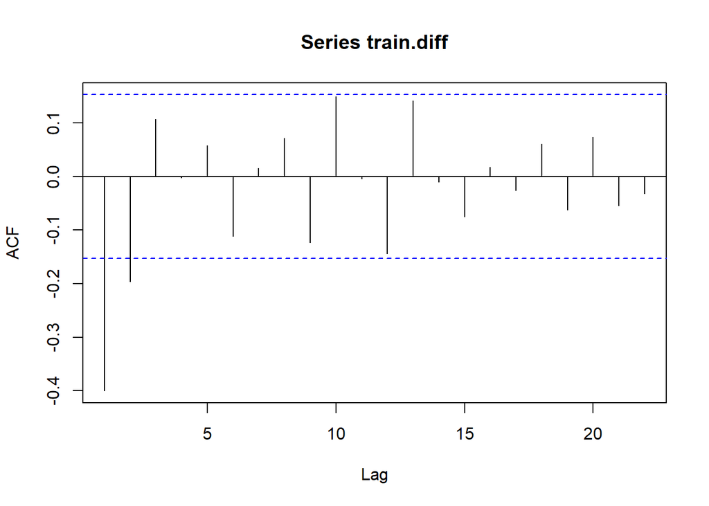

```r
acf(train.diff)
```

Berdasarkan plot tersebut, terlihat bahwa plot ACF cenderung *cuts off* pada lag ke 2, sehingga jika plot PACF dianggap *tails of*, maka model tentatifnya adalah ARIMA(0,2,2).

### Plot PACF

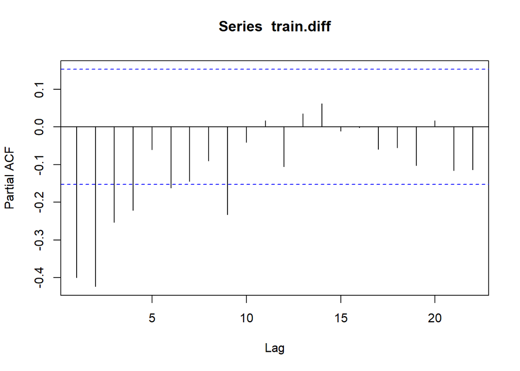

```r
pacf(train.diff)
```

Berdasarkan plot tersebut, terlihat bahwa plot PACF cenderung *cuts off* pada lag ke 9

### Plot EACF

```r
eacf(train.diff)
```

```
## AR/MA
##   0 1 2 3 4 5 6 7 8 9 10 11 12 13
## 0 x x o o o o o o o o o  o  o  o
## 1 x x o o o o o o o o o  o  o  o
## 2 x x x o o o o o o o o  o  o  o
## 3 x x o x o o o o o o o  o  o  o
## 4 x x o x o o o o o o o  o  o  o
## 5 x x x x o x o o o o o  o  o  o
## 6 x o x o o o o o o o o  o  o  o
## 7 x o x o x o o x o o o  o  o  o
```

Identifikasi model menggunakan plot EACF dilakukan dengan melihat ujung segitiga pada pola segitiga nol. Dalam hal ini model tentatif yang terbentuk adalah ARIMA(0,2,2), ARIMA(0,2,3), ARIMA(1,2,2), dan ARIMA(1,2,3).

# Pendugaan Parameter Model Tentatif

## ARIMA(0,2,2)

```r
library(forecast)
model1.da=Arima(train.diff, order=c(0,2,2),method="ML")
summary(model1.da) #AIC=-135.11
```

```
## Series: train.diff
## ARIMA(0,2,2)
##
## Coefficients:
##           ma1     ma2
##       -1.9949  0.9999
## s.e.   0.0225  0.0216
##
## sigma^2 = 0.02287:  log likelihood = 70.56
## AIC=-135.11   AICc=-134.96   BIC=-125.83
##
## Training set error measures:
##                         ME      RMSE       MAE      MPE    MAPE      MASE
## Training set -0.0009102076 0.1493921 0.1149185 100.8073 105.628 0.5954941
##                    ACF1
## Training set -0.3920374
```

```r
lmtest::coeftest(model1.da) #seluruh parameter signifikan
```

```
##
## z test of coefficients:
##
##      Estimate Std. Error z value  Pr(>|z|)
## ma1 -1.994942   0.022546 -88.482 < 2.2e-16 ***
## ma2  0.999881   0.021645  46.194 < 2.2e-16 ***
## ---
## Signif. codes:  0 '***' 0.001 '**' 0.01 '*' 0.05 '.' 0.1 ' ' 1
```

## ARIMA(0,2,3)

```r
model2.da=Arima(train.diff, order=c(0,2,3),method="ML")
summary(model2.da) #AIC=-211.08
```

```
## Series: train.diff
## ARIMA(0,2,3)
##
## Coefficients:
##           ma1     ma2      ma3
##       -2.9128  2.8275  -0.9147
## s.e.   0.0086  0.0165   0.0084
##
## sigma^2 = 0.01323:  log likelihood = 109.54
## AIC=-211.08   AICc=-210.83   BIC=-198.71
##
## Training set error measures:
##                        ME      RMSE       MAE      MPE     MAPE      MASE
## Training set -0.001789336 0.1132724 0.0861668 72.82917 135.2259 0.4465062
##                    ACF1
## Training set 0.06236634
```

```r
lmtest::coeftest(model2.da) #seluruh parameter signifikan
```

```
##
## z test of coefficients:
##
##       Estimate Std. Error z value  Pr(>|z|)
## ma1 -2.9127940  0.0085802 -339.48 < 2.2e-16 ***
## ma2  2.8275167  0.0164785  171.59 < 2.2e-16 ***
## ma3 -0.9147068  0.0084332 -108.47 < 2.2e-16 ***
## ---
## Signif. codes:  0 '***' 0.001 '**' 0.01 '*' 0.05 '.' 0.1 ' ' 1
```

#### ARIMA(1,2,2)

```r
model3.da=Arima(train.diff, order=c(1,2,2),method="ML")
summary(model3.da) #AIC=-159.64
```

```
## Series: train.diff
## ARIMA(1,2,2)
##
## Coefficients:
##           ar1      ma1     ma2
##       -0.3882  -1.9966  1.0000
## s.e.   0.0719   0.0224  0.0221
##
## sigma^2 = 0.01934:  log likelihood = 83.82
## AIC=-159.64   AICc=-159.39   BIC=-147.26
##
## Training set error measures:
##                        ME     RMSE       MAE      MPE     MAPE      MASE
## Training set -9.22867e-05 0.136934 0.1051585 78.58966 119.2912 0.5449189
##                    ACF1
## Training set -0.1667322
```

```r
lmtest::coeftest(model3.da) #seluruh parameter signifikan
```

```
##
## z test of coefficients:
##
##      Estimate Std. Error  z value  Pr(>|z|)
## ar1 -0.388159   0.071866  -5.4012 6.621e-08 ***
## ma1 -1.996573   0.022434 -88.9980 < 2.2e-16 ***
## ma2  0.999986   0.022070  45.3103 < 2.2e-16 ***
## ---
## Signif. codes:  0 '***' 0.001 '**' 0.01 '*' 0.05 '.' 0.1 ' ' 1
```

```r
model4.da=Arima(train.diff, order=c(1,1,1),method="ML")
summary(model4.da) #AIC=-174.77
```

```
## Series: train.diff
## ARIMA(1,1,1)
##
## Coefficients:
##           ar1      ma1
##       -0.3939  -1.0000
## s.e.   0.0714   0.0152
##
## sigma^2 = 0.01899:  log likelihood = 90.39
## AIC=-174.77   AICc=-174.62   BIC=-165.47
##
## Training set error measures:
##                        ME     RMSE       MAE      MPE     MAPE      MASE
## Training set 0.0004450936 0.136531 0.1043639 75.65932 119.5021 0.5408017
##                    ACF1
## Training set -0.1710108
```

```r
lmtest::coeftest(model4.da) #seluruh parameter signifikan
```

```
##
## z test of coefficients:
##
##      Estimate Std. Error  z value  Pr(>|z|)
## ar1 -0.393882   0.071414  -5.5155 3.478e-08 ***
## ma1 -1.000000   0.015156 -65.9813 < 2.2e-16 ***
## ---
## Signif. codes:  0 '***' 0.001 '**' 0.01 '*' 0.05 '.' 0.1 ' ' 1
```

Berdasarkan pendugaan parameter di atas, nilai AIC terkecil dimiliki oleh model ARIMA(0,2,3) lalu juga seluruhnya signifikan sehingga model yang dipilih adalah model ARIMA(0,2,3).

## Analisis Sisaan

Model terbaik hasil identifikasi kemudian dicek asumsi sisaannya. Sisaan model ARIMA harus memenuhi asumsi normalitas, kebebasan sisaan, dan kehomogenan ragam. Diagnostik model dilakukan secara eksplorasi dan uji formal.

### Eksplorasi Sisaan

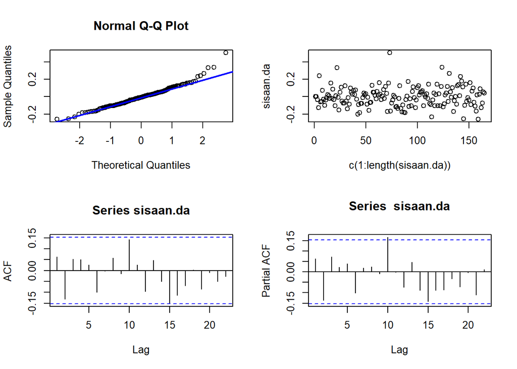

```r
#Eksplorasi
sisaan.da <- model2.da$residuals
par(mfrow=c(2,2))
qqnorm(sisaan.da)
qqline(sisaan.da, col = "blue", lwd = 2)
plot(c(1:length(sisaan.da)),sisaan.da)
acf(sisaan.da)
pacf(sisaan.da)
```

```r
par(mfrow = c(1,1))
```

### Uji Formal

```r
#1) Sisaan Menyebar Normal
ks.test(sisaan.da,"pnorm")  #tolak H0 > sisaan tidak menyebar normal
```

```
##
##  Asymptotic one-sample Kolmogorov-Smirnov test
##
## data:  sisaan.da
## D = 0.40247, p-value < 2.2e-16
## alternative hypothesis: two-sided
```

Selain dengan eksplorasi, asumsi tersebut dapat diuji menggunakan uji formal. Pada tahapan ini uji formal yang digunakan untuk normalitas adalah uji Kolmogorov-Smirnov (KS). Hipotesis pada uji KS adalah sebagai berikut.

$H_0$ : Sisaan menyebar normal

$H_1$ : Sisaan tidak menyebar normal

Berdasarkan uji KS tersebut, didapat *p-value* sebesar 2.2e-16 yang kurang dari taraf nyata 5% sehingga tolak $H_0$ dan menandakan bahwa sisaan tidak menyebar normal.

```r
#2) Sisaan saling bebas/tidak ada autokorelasi
Box.test(sisaan.da, type = "Ljung")  #tak tolak H0 > sisaan saling bebas
```

```
##
##  Box-Ljung test
##
## data:  sisaan.da
## X-squared = 0.65352, df = 1, p-value = 0.4189
```

Selanjutnya akan dilakukan uji formal untuk kebebasan sisaan menggunakan uji Ljung-Box. Hipotesis yang digunakan adalah sebagai berikut.

$H_0$ : Sisaan saling bebas

$H_1$ : Sisaan tidak tidak saling bebas

Berdasarkan uji Ljung-Box tersebut, didapat *p-value* sebesar 0.4189 yang lebih besar dari taraf nyata 5% sehingga tak tolak $H_0$ dan menandakan bahwa sisaan saling bebas.

```r
#3) Sisaan homogen
Box.test((sisaan.da)^2, type = "Ljung")  #tak tolak H0 > sisaan homogen
```

```
##
##  Box-Ljung test
##
## data:  (sisaan.da)^2
## X-squared = 0.19313, df = 1, p-value = 0.6603
```

Hipotesis yang digunakan untuk uji kehomogenan ragam adalah sebagai berikut.

$H_0$ : Ragam sisaan homogen

$H_1$ : Ragam sisaan tidak homogen

```r
#4) Nilai tengah sisaan sama dengan nol
t.test(sisaan.da, mu = 0, conf.level = 0.95)  #tak tolak h0 > nilai tengah sisaan sama dengan 0
```

```
##
##  One Sample t-test
##
## data:  sisaan.da
## t = -0.20232, df = 164, p-value = 0.8399
## alternative hypothesis: true mean is not equal to 0
## 95 percent confidence interval:
##  -0.01925210  0.01567342
## sample estimates:
##    mean of x
## -0.001789336
```

Terakhir, dengan uji-t, akan dicek apakah nilai tengah sisaan sama dengan nol. Hipotesis yang diujikan sebagai berikut.

$H_0$ : nilai tengah sisaan sama dengan 0

$H_1$ : nilai tengah sisaan tidak sama dengan 0

Berdasarkan uji-ttersebut, didapat *p-value* sebesar 0.8399 yang lebih besar dari taraf nyata 5% sehingga tak tolak $H_0$ dan menandakan bahwa nilai tengah sisaan sama dengan nol.

## Overfitting

Tahapan selanjutnya adalah *overfitting* dilakukan dengan menaikkan orde AR(p) dan MA(q) dari model ARIMA(0,2,3) untuk melihat apakah terdapat model lain yang lebih baik dari model saat ini. Kandidat model *overfitting* adalah ARIMA(0,2,4) dan ARIMA(1,2,3).

```r
#---OVERFITTING---#
model1a.ma2=Arima(train.diff, order=c(0,2,4),method="ML")
summary(model1a.ma2) #-210.26
```

```
## Series: train.diff
## ARIMA(0,2,4)
##
## Coefficients:
##           ma1     ma2      ma3      ma4
##       -2.7703  2.3679  -0.4236  -0.1739
## s.e.   0.0053  0.0111   0.0108   0.0050
##
## sigma^2 = 0.01306:  log likelihood = 110.13
## AIC=-210.26   AICc=-209.88   BIC=-194.79
##
## Training set error measures:
##                       ME      RMSE        MAE      MPE     MAPE      MASE
## Training set 3.10305e-06 0.1121883 0.08456663 76.50269 117.5336 0.4382143
##                     ACF1
## Training set -0.07572612
```

```r
lmtest::coeftest(model1a.ma2)
```

```
##
## z test of coefficients:
##
##       Estimate Std. Error  z value  Pr(>|z|)
## ma1 -2.7703055  0.0053103 -521.688 < 2.2e-16 ***
## ma2  2.3679032  0.0111236  212.873 < 2.2e-16 ***
## ma3 -0.4236365  0.0108245  -39.137 < 2.2e-16 ***
## ma4 -0.1739321  0.0049961  -34.813 < 2.2e-16 ***
## ---
## Signif. codes:  0 '***' 0.001 '**' 0.01 '*' 0.05 '.' 0.1 ' ' 1
```

```r
model1b.ma2=Arima(train.diff, order=c(1,2,3),method="ML")
summary(model1b.ma2) #-206
```

```
## Series: train.diff
## ARIMA(1,2,3)
##
## Coefficients:
```

```
##           ar1      ma1     ma2      ma3
##       -0.0018  -2.7868  2.5796  -0.7924
## s.e.   0.0666      NaN     NaN      NaN
##
## sigma^2 = 0.0141:  log likelihood = 108
## AIC=-206   AICc=-205.62   BIC=-190.53
##
## Training set error measures:
##                       ME      RMSE        MAE      MPE    MAPE      MASE
## Training set -0.00167098 0.1165583 0.08886875 74.62761 134.573 0.4605074
##                      ACF1
## Training set -0.002725034
```

```r
lmtest::coeftest(model1b.ma2)
```

```
##
## z test of coefficients:
##
##       Estimate Std. Error z value Pr(>|z|)
## ar1 -0.0017799  0.0666285 -0.0267   0.9787
## ma1 -2.7868171        NaN     NaN      NaN
## ma2  2.5796003        NaN     NaN      NaN
## ma3 -0.7924224        NaN     NaN      NaN
```

```r
#model yang dipilih adalah model awal, yaitu ARIMA(0,2,3) karena nilai AIC lebih kecil
```

# Peramalan

```r
#---FORECAST---#
ramalan.da <- forecast::forecast(model2.da, h = 42)
ramalan.da
```

```
##     Point Forecast      Lo 80     Hi 80      Lo 95     Hi 95
## 168  -3.643863e-02 -0.1843827 0.1115055 -0.2626996 0.1898224
## 169  -3.671338e-05 -0.1996327 0.1995593 -0.3052924 0.3052190
## 170  -3.889028e-05 -0.1996352 0.1995574 -0.3052950 0.3052173
## 171  -4.106718e-05 -0.1996376 0.1995555 -0.3052976 0.3052155
## 172  -4.324408e-05 -0.1996401 0.1995536 -0.3053003 0.3052138
## 173  -4.542098e-05 -0.1996426 0.1995517 -0.3053029 0.3052120
## 174  -4.759788e-05 -0.1996450 0.1995498 -0.3053055 0.3052103
## 175  -4.977478e-05 -0.1996475 0.1995480 -0.3053082 0.3052086
## 176  -5.195168e-05 -0.1996500 0.1995461 -0.3053108 0.3052069
## 177  -5.412858e-05 -0.1996525 0.1995442 -0.3053135 0.3052052
## 178  -5.630548e-05 -0.1996550 0.1995424 -0.3053161 0.3052035
## 179  -5.848238e-05 -0.1996575 0.1995405 -0.3053188 0.3052018
## 180  -6.065928e-05 -0.1996600 0.1995387 -0.3053215 0.3052001
## 181  -6.283618e-05 -0.1996625 0.1995368 -0.3053241 0.3051985
```

[output cut: 28 more lines]

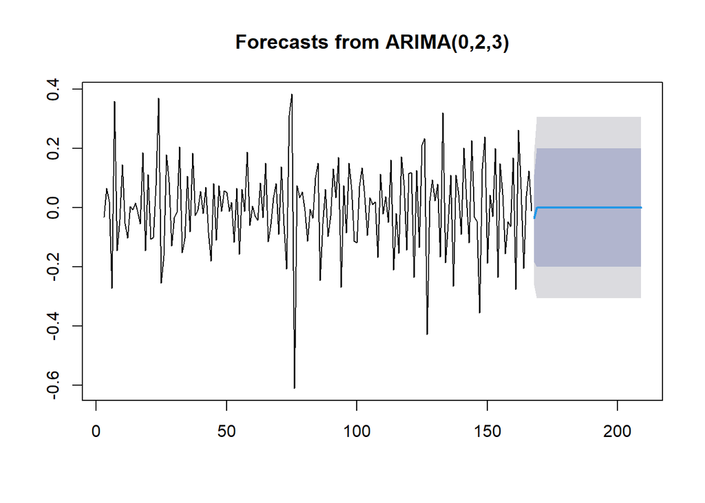

```r
data.ramalan.da <- ramalan.da$mean
plot(ramalan.da)
```

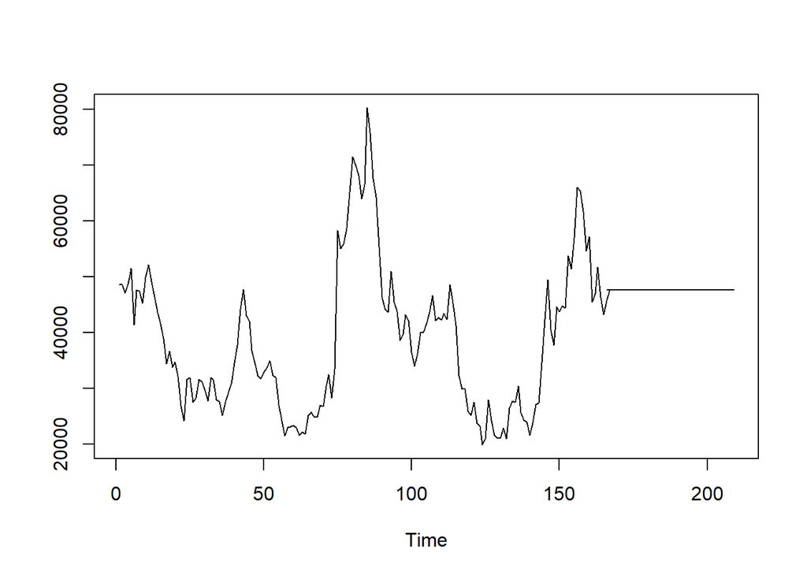

```r
pt_1 <- train.ts[167] #nilai akhir data latih
hasil.forc.Diff <- data.ramalan.da
hasil <- diffinv(hasil.forc.Diff, differences = 2) + pt_1
#has.1 sama hasilnta dengan: cumsum(c(pt_1,hasil.forc.Diff))
ts.plot(train.ts,hasil)
```

Berdasarkan hasil plot ramalan di atas, dapat dilihat bahwa ramalan ARIMA(0,2,3) cenderung stabil hingga akhir periode. Selanjutnya, dapat dicari nilai akurasi antara hasil ramalan dengan data uji sebagai berikut.

```r
perbandingan.da<-matrix(data=c(head(test.ts, n=42), hasil[-1]),
                     nrow = 42, ncol = 2)
colnames(perbandingan.da)<-c("Aktual","Hasil Forecast")
perbandingan.da
```

```
##       Aktual Hasil Forecast
##  [1,]  48650       47650.00
##  [2,]  50150       47649.96
##  [3,]  50750       47649.93
##  [4,]  49250       47649.89
##  [5,]  44650       47649.85
##  [6,]  43150       47649.82
##  [7,]  31250       47649.78
##  [8,]  31250       47649.74
##  [9,]  37150       47649.71
## [10,]  36900       47649.67
## [11,]  28400       47649.63
## [12,]  26650       47649.60
## [13,]  25400       47649.56
## [14,]  22650       47649.52
```

[output cut: 28 more lines]

```r
accuracy(ts(hasil[-1]), head(test.ts, n=42))
```

```
##                 ME     RMSE      MAE       MPE     MAPE      ACF1 Theil's U
## Test set -12021.86 15469.12 13067.29 -44.24551 46.23227 0.8606736  4.451288
```

Nilai MAPE 46%. Berarti model masih kurang baik dalam memprediksi nilai harga cabe keriting di provinsi Sumatra Barat diakrenakan data bersifat seasonal dan kemungkinan akan lebih baik jika menggunakan model SARIMA.